# CHL5230-K-Means (1)

Introduction to Linear Algebra

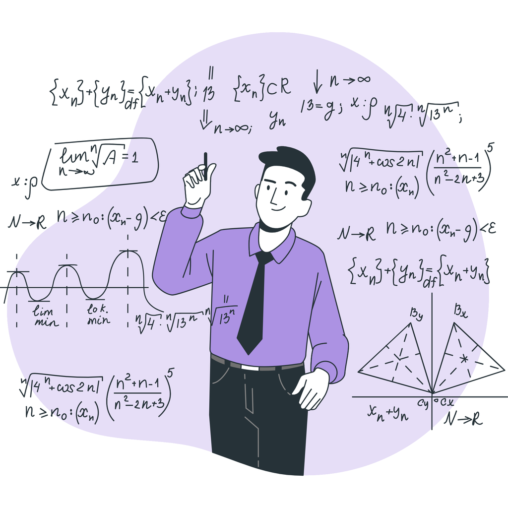

### The Importance of Linear Algebra in Machine Learning

Linear algebra, a fundamental branch of mathematics, explores vectors, matrices, linear equations, and vector spaces. For those venturing into the world of machine learning, understanding these concepts is essential. While it is possible to use pre-existing machine learning models without a deep grasp of linear algebra, a solid understanding of these mathematical principles enhances your comprehension and enables more informed algorithm applications.

In this tutorial, we aim to provide a concise overview of key linear algebra concepts and their practical use in `Python`. Our focus is on intuitive understanding, avoiding complex mathematical terminology. A basic mathematical foundation is all you need for this exploration.

Let's embark on this enlightening journey!

**Note**: Please check the `ml-resources` channel on Slack for more references on this topic.

Vectors

Vectors can be arranged either vertically or horizontally, signifying whether they are visualized as a row or a column of numbers. Here are some illustrative examples:

$x = [1, 5, -2, 1.5]$ $y = \begin{bmatrix} 1 \\ 5 \\ -2 \\ 1.5 \end{bmatrix}$ $z = [0, 2, \frac{1}{2}]$

In this context, $x$ and $y$ are 4-dimensional vectors. Though they possess identical elements, they are distinct vectors: $x$ is a row vector while $y$ is a column vector. On the other hand, $z$ is a 3-dimensional row vector.

Conventionally in linear algebra, vectors are assumed to be column-oriented unless specified otherwise. Sometimes, to represent a vector, we use an arrow notation like $\vec{v}$. The transpose of a vector, denoted as $v^t$, flips its orientation. That is, the transpose of a column vector yields a row vector and vice-versa.

$v = [1, 2, 3]$ $v^t = \begin{bmatrix} 1 \\ 2 \\ 3 \end{bmatrix}$

Geometrically, a vector can be interpreted as an arrow characterized by its angle and magnitude within a $R^N$ space. We often visualize it as an arrow originating from the coordinate origin, pointing towards its specific coordinates. While it is straightforward to graphically depict this in 2D or 3D spaces, higher dimensions require a touch of imagination. We will provide visual aids shortly.

In Python, the `numpy` library is pivotal for operations involving vectors, matrices, and other linear algebraic entities. Let's proceed with creating some vectors in code.

```python
# Import necessary libraries
import numpy as np

# Create a 2D vector using numpy's array function
v = np.array([1, 2])

# Display the created vector
print(v)
```

```
[1 2]
```

Working with Vectors: Shape and Orientation

When working with vectors in machine learning and linear algebra, understanding their shape and orientation is crucial. In this section, we'll delve into creating vectors using the `numpy` library and explore how to discern their shapes.

```python
v = np.array([1, 2]) # Creating a 1D vector
print(v.shape) # Outputting the shape of the vector
```

```
(2,)
```

Differentiating Between Row and Column Vectors– The vector we have just created, `v`, does not explicitly specify its orientation as row or column. However, in various applications, particularly in matrix operations, the distinction is vital. Here is how you can specifically create row and column vectors:

```python
row_vector = np.array([[1, 2]]) # Creating a row vector
column_vector = np.array([[1], [2]]) # Creating a column vector

print(row_vector.shape) # Displays $1, 2), meaning 1 row and 2 columns
print(column_vector.shape) # Displays $2, 1), meaning 2 rows and 1 column
```

```
(1, 2)
(2, 1)
```

Notice the difference in the way we define these vectors. A row vector is a 2D list with one inner list, while a column vector comprises multiple 1D lists.

Transposing Vectors– In linear algebra, **transposition** flips a matrix's orientation. For vectors, this means changing a row vector to a column vector and vice-versa. Using `.T` on a `numpy` array will transpose it.

In this case, the row vector will be flipped into a column vector.

```python
print(row_vector.T) # Transposes and outputs the row_vector
```

```
[[1]
 [2]]
```

Vector Operations and Visualization

Vectors can be imagined as arrows in space, originating from the origin and terminating at a specific point determined by the vector's components.

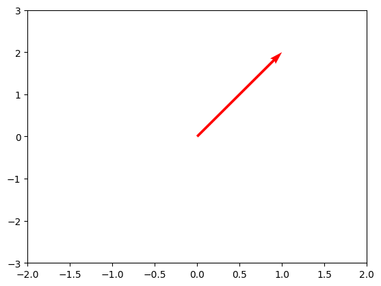

```python
import numpy as np
import matplotlib.pyplot as plt

v = np.array([1, 2]) # Define a 2D vector

# Visualizing the vector
plt.quiver([0], [0], v[0], v[1], angles='xy', scale_units='xy', color=['r'], scale=1)
plt.xlim(-v[0] -1 , v[0] + 1)
plt.ylim(-v[1] -1 , v[1] + 1)
plt.show()
```

**Adding Vectors–** Vectors can be added element-wise, provided they have the same dimension.

For instance:

$$ \begin{bmatrix} 1 \\ 2 \\ 0.5 \\ \end{bmatrix} + \begin{bmatrix} 2.5 \\ -2 \\ 5\\ \end{bmatrix} = \begin{bmatrix} 3.5 \\ 0 \\ 5.5 \\ \end{bmatrix} $$

This operation in Python:

```python
v1 = np.array([1, 2, .5])
v2 = np.array([2.5, -2, 5])
result = v1 + v2 # Adding vectors
print(result)
```

```
[3.5 0.  5.5]
```

Geometrically, vector addition can be visualized as follows:

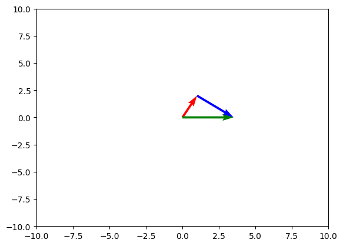

```python
v1 = np.array([1, 2])
v2 = np.array([2.5, -2])
sum_vec = v1 + v2

# Visualization
plt.quiver([0, v1[0], 0], [0, v1[1], 0], [v1[0], v2[0], sum_vec[0]], [v1[1], v2[1], sum_vec[1]], angles='xy', scale_units='xy', color=['r','b','g'], scale=1)
plt.xlim(-10 , 10)
plt.ylim(-10 , 10)
plt.show()
```

**Subtracting Vectors–**Vector subtraction is analogous to addition and is done element-wise.

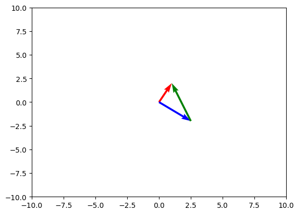

```python
subtract_result = v1 - v2

# Visualization
plt.quiver([0, 0, v2[0]], [0, 0, v2[1]], [v1[0], v2[0], subtract_result[0]], [v1[1], v2[1], subtract_result[1]], angles='xy', scale_units='xy', color=['r','b','g'], scale=1)
plt.xlim(-10 , 10)
plt.ylim(-10 , 10)
plt.show()
```

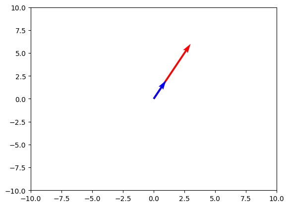

```python
multiplier = 3
scaled_v = multiplier * v

# Visualization
plt.quiver([0, 0], [0, 0], [scaled_v[0], v[0]], [scaled_v[1], v[1]], angles='xy', scale_units='xy', color=['r','b','g'], scale=1)
plt.xlim(-10 , 10)
plt.ylim(-10 , 10)
plt.show()
```

$$ ||v|| = \sqrt{\sum_{n=0}^{N} v_i^2} $$

In Python, it can be computed as:

```python
v_norm = np.linalg.norm(v)
print(v_norm)
```

```
2.23606797749979
```

**Unit Vector–**A vector with a norm of 1 is a unit vector. Any vector can be rescaled to a unit vector by dividing it by its norm.

```python
unit_v = v / v_norm
unit_v_norm = np.linalg.norm(unit_v)
print(unit_v_norm) # Approaching 1
```

```
0.9999999999999999
```

Dot Product

$x = [x_1, x_2, ..., x_n]$ $y = [y_1, y_2, ..., y_n]$

Their dot product is: $x^Ty = \sum_{i=1}^{n} x_i \times y_i$

It is essential to ensure the vectors have the same dimension when computing the dot product.

```python
x = np.array([1, 2, 3])
y = np.array([2, 3, 4])
print(np.dot(x, y))
```

```
20
```

Matrices

A matrix can be thought of as a collection of column vectors side by side, or row vectors stacked on top of each other. Alternatively, you can visualize a matrix as a table of numbers with rows and columns. A matrix with n rows and m columns is denoted as:

$x = \begin{bmatrix} x_{11} & x_{12} & \dots & x_{1m} \\ x_{21} & x_{22} & \dots & x_{2m} \\ \vdots & \vdots & \ddots & \vdots \\ x_{n1} & x_{n2} & \dots & x_{nm} \\ \end{bmatrix} $ Where $x \in \mathbb{R}^{N \times M}$ signifies that x is an $N \times M$ matrix.

```python
x = np.array([[1, 2, 3],
              [3, 4, 5]]) # Define matrices in Python similar to vectors
print(x)
print(x.shape) # Output shape of matrix
```

```
[[1 2 3]
 [3 4 5]]
(2, 3)
```

Matrix operations are similar to vectors. We can perform element-wise addition and subtraction and scalar multiplication. There are also several special types of matrices:

- **Square Matrix:** A matrix with an equal number of rows and columns.
- **Diagonal Matrix:** Only non-zero elements exist on the main diagonal. $ \begin{bmatrix} 1 & 0 & 0 \\ 0 & -2 & 0 \\ 0 & 0 & 0 \\ \end{bmatrix}$
- **Triangular Matrix:** Contains zeros either above or below the main diagonal. Based on this, matrices can be upper-triangular or lower-triangular.

  $\text{Lower triangular:} \begin{bmatrix} 1 & 0 & 0 \\ 4 & -2 & 0 \\ 2 & 5 & -1 \\ \end{bmatrix}$

  $\text{Upper triangular:} \begin{bmatrix} 1 & 0 & 2 & 35 \\ 0 & -2 & 20 & 4 \\ 0 & 0 & 3 & 1.5 \\ 0 & 0 & 0 & 0 \\ \end{bmatrix}$
- **Identity Matrix:** A square matrix with 1s on the diagonal and 0s elsewhere. Multiplying any matrix by the identity matrix results in the original matrix.

  $I = \begin{bmatrix} 1 & 0 & 0 & 0 \\ 0 & 1 & 0 & 0 \\ 0 & 0 & 1 & 0 \\ 0 & 0 & 0 & 1 \\ \end{bmatrix}$

```python
I = np.eye(4) # Generate a 4x4 identity matrix
print(I)
```

```
[[1. 0. 0. 0.]
 [0. 1. 0. 0.]
 [0. 0. 1. 0.]
 [0. 0. 0. 1.]]
```

Matrix Multiplication

Matrix multiplication is more intricate than the element-wise operations. For two matrices $A \in \mathbb{R}^{N \times K}$ and $B \in \mathbb{R}^{P \times M}$, the product $AB$ is only defined if $K = P$, resulting

in a matrix of size $N \times M$. Thus, matrix multiplication is not commutative, meaning $AB \neq BA$ in general.

The element $c_{ij}$ in the resulting matrix $C$ is the dot product of the $i$-th row of $A$ and the $j$-th column of $B$:

$c_{ij} = \sum_{k=1}^{K} a_{ik} \times b_{kj}$

Matrix-vector multiplication follows the same principle, as vectors can be viewed as matrices with a single column or row.

```python
a = np.array([[1, 2, 3], [4, 5, 6]])
b = np.array([[1, 2, 5], [1, 4, 0], [0.5, 5, -2]])
result = a @ b # @ is used for matrix multiplication in Python
print(result)
```

```
[[ 4.5 25.  -1. ]
 [12.  58.   8. ]]
```

Matrix Transposition

Transposition of a matrix involves switching its rows with its columns. If $A \in \mathbb{R}^{N \times M}$, then its transpose $A^T$ is in $\mathbb{R}^{M \times N}$, and the elements of $A^T$ are given by $a^T_{ij} = a_{ji}$.

```python
a = np.array([[1, 2, 3], [4, 5, 6]])
print(a.shape)
print(a.T.shape) # Shape after transposition
print(a.T) # Transposed matrix
```

```
(2, 3)
(3, 2)
[[1 4]
 [2 5]
 [3 6]]
```

K-Means Clustering

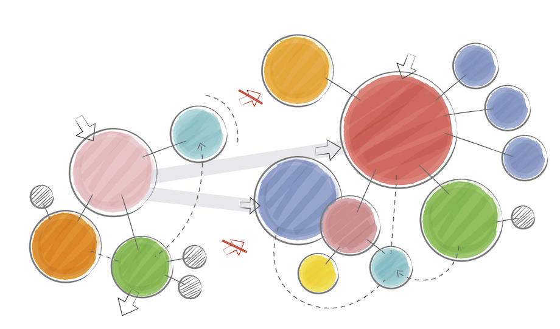

K-means is a popular clustering algorithm used to partition data into `k` distinct, non-overlapping clusters. In this tutorial, we will walk through the process of using K-means to cluster data from a public health dataset.

**Data Loading and Exploration–**Before diving into clustering, let's first load our data and perform some preliminary exploration.

```python
import pandas as pd
import numpy as np
import matplotlib.pyplot as plt

# Load the dataset
df = pd.read_csv('insurance.csv')
df.head()
```

|  | age | sex | bmi | children | smoker | region | charges |
| --- | --- | --- | --- | --- | --- | --- | --- |
| 0 | 19 | female | 27.900 | 0 | yes | southwest | 16884.92400 |
| 1 | 18 | male | 33.770 | 1 | no | southeast | 1725.55230 |
| 2 | 28 | male | 33.000 | 3 | no | southeast | 4449.46200 |
| 3 | 33 | male | 22.705 | 0 | no | northwest | 21984.47061 |
| 4 | 32 | male | 28.880 | 0 | no | northwest | 3866.85520 |

Upon loading the data, let's perform some basic data cleaning to ensure that it's ready for analysis.

```python
# Check for missing values in the dataset
print(df.isna().sum())

# Display the data types of each column
df.dtypes
```

```
age         0
sex         0
bmi         0
children    0
smoker      0
region      0
charges     0
dtype: int64
```

```
age           int64
sex          object
bmi         float64
children      int64
smoker       object
region       object
charges     float64
dtype: object
```

**Feature Engineering–**Sometimes, the raw features in the dataset are not sufficient or apt for the analysis we want to perform. Feature engineering is the process of creating new features that better capture the information in the dataset.

```python
# Adding a binary column to indicate if a person has children or not
df['has_any_children'] = df['children'] > 0
df.head()
```

|  | age | sex | bmi | children | smoker | region | charges | has_any_children |
| --- | --- | --- | --- | --- | --- | --- | --- | --- |
| 0 | 19 | female | 27.900 | 0 | yes | southwest | 16884.92400 | False |
| 1 | 18 | male | 33.770 | 1 | no | southeast | 1725.55230 | True |
| 2 | 28 | male | 33.000 | 3 | no | southeast | 4449.46200 | True |
| 3 | 33 | male | 22.705 | 0 | no | northwest | 21984.47061 | False |
| 4 | 32 | male | 28.880 | 0 | no | northwest | 3866.85520 | False |

Additionally, we can convert categorical variables into a format suitable for machine learning algorithms.

```python
# Convert the 'smoker' column to boolean values
df['smoker'] = df['smoker'] == 'yes'
df.head()

# One-hot encode the 'region' column
region_dummies = pd.get_dummies(df['region'])
df = pd.concat([df, region_dummies], axis=1)
df.head()
```

|  | age | sex | bmi | children | smoker | region | charges | has_any_children | northeast | northwest | southeast | southwest |
| --- | --- | --- | --- | --- | --- | --- | --- | --- | --- | --- | --- | --- |
| 0 | 19 | female | 27.900 | 0 | True | southwest | 16884.92400 | False | 0 | 0 | 0 | 1 |
| 1 | 18 | male | 33.770 | 1 | False | southeast | 1725.55230 | True | 0 | 0 | 1 | 0 |
| 2 | 28 | male | 33.000 | 3 | False | southeast | 4449.46200 | True | 0 | 0 | 1 | 0 |
| 3 | 33 | male | 22.705 | 0 | False | northwest | 21984.47061 | False | 0 | 1 | 0 | 0 |
| 4 | 32 | male | 28.880 | 0 | False | northwest | 3866.85520 | False | 0 | 1 | 0 | 0 |

**Initial Data Visualization–**Visualizing the data can offer insights about its distribution and potential clusters.

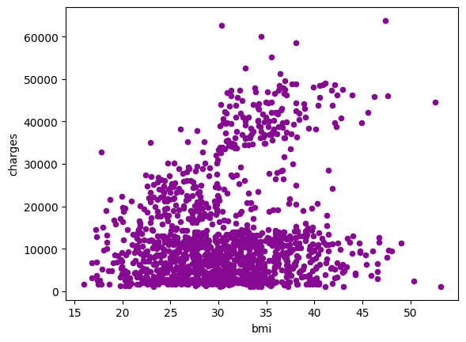

```python
features = ['bmi', 'charges']
df[features].plot.scatter(x=features[0], y=features[1], color='#860991')
plt.show()
```

**Normalizing Data for Improved Results–**Data normalization can often lead to better clustering results since it ensures all features contribute equally to the result.

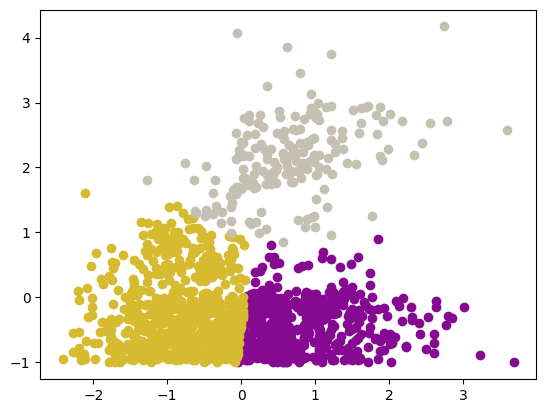

```python
# Required libraries
from sklearn.cluster import KMeans
from sklearn.preprocessing import StandardScaler
import matplotlib.pyplot as plt

# Function to visualize the clustering results
def plot_clusters(x, labels, k):
    # Define colors for each cluster
    colors = ['#860991', '#d6ba2f', '#c4c1b3']
    # Loop through each cluster
    for i in range(k):
        # Filter the data points that belong to the current cluster
        filtered_label0 = x[labels == i]
        # Plot the filtered data points using the corresponding color
        plt.scatter(filtered_label0[:, 0], filtered_label0[:, 1], c=colors[i])
    # Display the plot
    plt.show()

# Choose two features, 'bmi' and 'charges', for clustering and visualization
features = ['bmi', 'charges']

# Convert the selected features from DataFrame to a NumPy array for easier processing with sklearn
data =  df[features].to_numpy()

# Standardize the data - this makes the mean 0 and standard deviation 1 for each feature
# Standardization can help the k-means algorithm perform better as it's sensitive to feature scales
st_x = StandardScaler()
data = st_x.fit_transform(data)

# Apply k-means clustering on the standardized data
# Here, we're specifying 3 clusters with a fixed random state for reproducibility
kmeans = KMeans(n_clusters=3, random_state=0)
label = kmeans.fit_predict(data)

# Visualize the clustering results using the defined function
plot_clusters(data, label, 3)
```

If you do not normalize (or standardize) the data before applying k-means clustering, the clustering algorithm may not perform as well, particularly if the scales of the features are very different. In the modified code below, the k-means algorithm is applied directly to the non-standardized data. As a result, if the scales of 'bmi' and 'charges' are very different, the feature with the larger scale ("charges" in this case) will dominate the clustering process, potentially leading to suboptimal clusters.

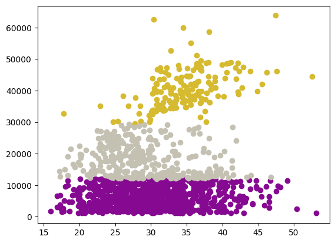

```python
# Required libraries
from sklearn.cluster import KMeans
from sklearn.preprocessing import StandardScaler
import matplotlib.pyplot as plt

# Function to visualize the clustering results
def plot_clusters(x, labels, k):
    # Define colors for each cluster
    colors = ['#860991', '#d6ba2f', '#c4c1b3']
    # Loop through each cluster
    for i in range(k):
        # Filter the data points that belong to the current cluster
        filtered_label0 = x[labels == i]
        # Plot the filtered data points using the corresponding color
        plt.scatter(filtered_label0[:, 0], filtered_label0[:, 1], c=colors[i])
    # Display the plot
    plt.show()

# Choose two features, 'bmi' and 'charges', for clustering and visualization
features = ['bmi', 'charges']

# Convert the selected features from DataFrame to a NumPy array for easier processing with sklearn
data =  df[features].to_numpy()

# Apply k-means clustering on the [raw] data
# Here, we're specifying 3 clusters with a fixed random state for reproducibility
kmeans = KMeans(n_clusters=3, random_state=0)
label = kmeans.fit_predict(data)

# Visualize the clustering results using the defined function
plot_clusters(data, label, 3)
```

All the materials and examples from this tutorial are accessible on [Google Colab](https://drive.google.com/file/d/1tiAKiSqEvDMtQLMXaFKay384L83yd621/view?usp=sharing). I encourage you to actively run, modify, and test the code to enhance your learning and adapt it to your unique queries and tasks.